# PSTAT131HW01

## Exercise 4: Make a box plot of hwy, grouped by cyl. Do you see a pattern? If so, what?

Yes there seems to be a pattern. In group setting the number of cyl increases the hwy tend to decrease with a few outliers.

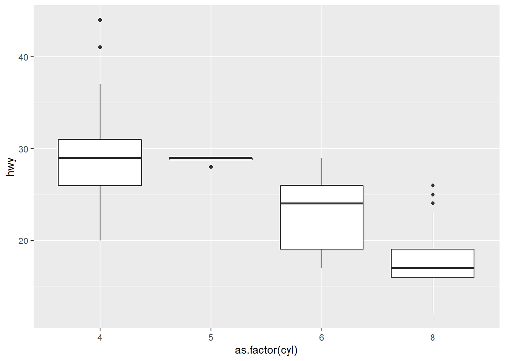

```r
ggplot(data = mpg, aes(x = as.factor(cyl), y = hwy)) +
  geom_boxplot()
```

## Exercise 5: Use the corrplot package to make a lower triangle correlation matrix of the mpg dataset. (Hint: You can find information on the package here.) Which variables are positively or negatively correlated with which others? Do these relationships make sense to you? Are there any that surprise you?

I only selected numeric variables, and the result for the numeric variables are not surprising, I dont know if any of them is not supposed to be like that since I dont know much about cars.Hwy and cty are positively correlated, year and cty is slightly negatively correlated, displ is negatively correlated with both cty and hwy, but is positively correlated with year, cyl is negatively correlated to both cty and hwy but is positively correlated with year and more so with displ.

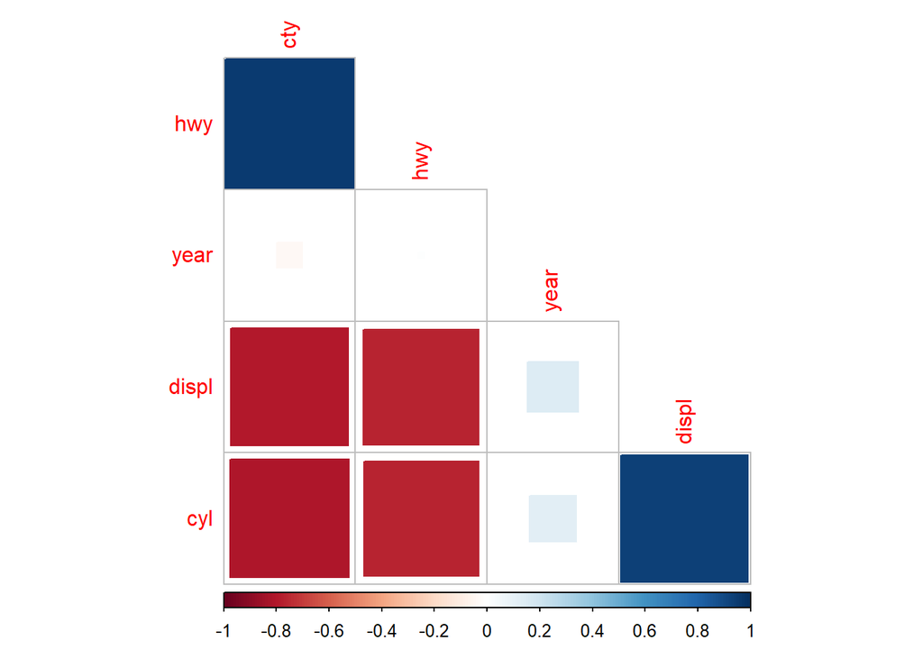

```r
num_mpg <- mpg %>%
  select(displ, year, cyl, cty, hwy)
M = cor(num_mpg)
corrplot(M, method = 'square', order = 'FPC', type = 'lower', diag = FALSE)
```